# Linear Regression in Python

This notebook demonstrates a simple linear regression analysis using Python to model Salary based on Years of Experience.

```python
import pandas as pd
```

Imports the pandas library and gives it a short name (pd). Pandas is a powerful Python library for working with tabular data (like spreadsheets or CSV files).

```python
dataset = pd.read_csv("regression_data.csv")
```

Reads a CSV file and loads it into a DataFrame, which is like a table in memory that you can work with in Python.

```python
import matplotlib.pyplot as plt
```

Loads the matplotlib plotting library, which is used to create charts and visualizations.

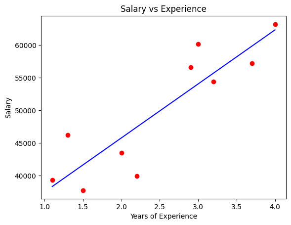

```python
plt.scatter(dataset["YearsExperience"], dataset["Salary"], color="red")
from sklearn.linear_model import LinearRegression
model = LinearRegression()
model.fit(dataset[["YearsExperience"]], dataset[["Salary"]])
plt.plot(dataset["YearsExperience"], model.predict(dataset[["YearsExperience"]]), color="blue")
plt.title("Salary vs Experience")
plt.xlabel("Years of Experience")
plt.ylabel("Salary")
plt.show()
```

**plt.scatter(x, y) :** Creates a scatter plot — red dots on a graph showing the original data points.

**from sklearn.linear_model import LinearRegression :** Imports the LinearRegression class from the scikit-learn (sklearn) library. Scikit-learn is a widely used machine learning library.

**model.fit(x, y) :** Fits the linear regression model to the data. X is the input (independent variable, must be 2D), y is the target (dependent variable).

**plt.plot(x, y_pred) :** Draws the regression line using predicted values. The blue line is the best-fit line the model calculates.

```python
correlation_coefficient = model.score(dataset[["YearsExperience"]], dataset[["Salary"]])  # R-squared
```

```python
print(f"Correlation coefficient = {correlation_coefficient:.3f}")
```

```
Correlation coefficient = 0.785
```